# Projects - Example Project for ECON 326

### Multicollinearity

As we know, multicollinearity is a common issue that arises in developing a regression. To test how this shows up in our current model, we will calculate variance inflation factors (VIF), using the package `car`.

> *Think Deeper*: Do you suspect any variables in the model may be affected by multicollinearity? How come?

```r
car::vif(mlr_1)
```

```
        gdp  population electricity
  29.840828   39.532929    4.915504
```

```r
coeftest(slr_3)
```

```
t test of coefficients:

              Estimate Std. Error t value  Pr(>|t|)
(Intercept) 2.3407e+04 5.9677e+03  3.9223 0.0001318 ***
population  1.2925e-02 1.2422e-03 10.4052 < 2.2e-16 ***
---
Signif. codes:  0 '***' 0.001 '**' 0.01 '*' 0.05 '.' 0.1 ' ' 1
```

```r
summary(slr_3)
```

```
Call:
lm(formula = CO2 ~ population, data = CO2_data)

Residuals:
   Min     1Q Median     3Q    Max
-63493 -23355 -20224 -12785 216382

Coefficients:
             Estimate Std. Error t value Pr(>|t|)
(Intercept) 2.341e+04  5.968e+03   3.922 0.000132 ***
population  1.293e-02  1.242e-03  10.405  < 2e-16 ***
---
Signif. codes:  0 '***' 0.001 '**' 0.01 '*' 0.05 '.' 0.1 ' ' 1

Residual standard error: 61210 on 154 degrees of freedom
Multiple R-squared:  0.4128,    Adjusted R-squared:  0.409
F-statistic: 108.3 on 1 and 154 DF,  p-value: < 2.2e-16
```

The high VIF indicate that there’s a problem with collinearity in our data. We’ll try to combat this by creating a model which combines the effects of `GDP` and `population` into a single variable of per capita GDP.

```r
#Create a new variable and view how it fits in the structure.
CO2_data$per_capita_gdp <- CO2_data$gdp/CO2_data$population
str(CO2_data)
```

```
tibble [156 × 39] (S3: tbl_df/tbl/data.frame)
 $ year           : num [1:156] 2009 2010 2011 2012 2013 ...
 $ province       : Factor w/ 13 levels "1","2","3","4",..: 1 1 1 1 1 1 1 1 1 1 ...
 $ DGUID.x        : chr [1:156] "2016A000210" "2016A000210" "2016A000210" "2016A000210" ...
 $ Value          : chr [1:156] "Chained (2012) dollars" "Chained (2012) dollars" "Chained (2012) dollars" "Chained (2012) dollars" ...
 $ NAICS          : chr [1:156] "All industries [T001]" "All industries [T001]" "All industries [T001]" "All industries [T001]" ...
 $ UOM.x          : chr [1:156] "Dollars" "Dollars" "Dollars" "Dollars" ...
 $ UOM_ID.x       : num [1:156] 81 81 81 81 81 81 81 81 81 81 ...
 $ SCALAR_FACTOR.x: chr [1:156] "millions" "millions" "millions" "millions" ...
 $ SCALAR_ID.x    : num [1:156] 6 6 6 6 6 6 6 6 6 6 ...
 $ VECTOR.x       : chr [1:156] "v62464519" "v62464519" "v62464519" "v62464519" ...
 $ COORDINATE.x   : chr [1:156] "1.2.1" "1.2.1" "1.2.1" "1.2.1" ...
 $ gdp            : num [1:156] 28944 30474 31376 29977 31486 ...
 $ STATUS.x       : logi [1:156] NA NA NA NA NA NA ...
 $ SYMBOL.x       : logi [1:156] NA NA NA NA NA NA ...
```

[output cut: 30 more lines]

```r
#Build a new model
mlr_2 <- lm(CO2 ~ per_capita_gdp + electricity, data = CO2_data)
summary(mlr_2)
```

```
Call:
lm(formula = CO2 ~ per_capita_gdp + electricity, data = CO2_data)

Residuals:
   Min     1Q Median     3Q    Max
-93135 -40891   5090  18764 193850

Coefficients:
                 Estimate Std. Error t value Pr(>|t|)
(Intercept)    -4.714e+04  1.777e+04  -2.653  0.00882 **
per_capita_gdp  1.182e+06  2.753e+05   4.292 3.13e-05 ***
electricity     9.986e-03  1.025e-03   9.738  < 2e-16 ***
---
Signif. codes:  0 '***' 0.001 '**' 0.01 '*' 0.05 '.' 0.1 ' ' 1

Residual standard error: 62530 on 153 degrees of freedom
Multiple R-squared:  0.3911,    Adjusted R-squared:  0.3831
F-statistic: 49.13 on 2 and 153 DF,  p-value: < 2.2e-16
```

```r
#Calculate VIF on the new model
car::vif(mlr_2)
```

```
per_capita_gdp    electricity
      1.070429       1.070429
```

This appears to have addressed out problems with multicollinearity in our model.

### Adding Other Variables

There is still another variable that we haven’t considered in our model. Let’s take a look at how `province` affects CO2. Since our these variables are expressed qualitative factors, they need to be represented by dummy variables. R does this automatically when a dummy is used in regression, and excludes the first category (in our case Newfoundland and Labrador) as the reference variable.

```r
slr_4 <- lm(CO2 ~ province, data = CO2_data)
summary(slr_4)
```

```
Call:
lm(formula = CO2 ~ province, data = CO2_data)

Residuals:
     Min       1Q   Median       3Q      Max
-24582.8   -749.2     20.4    954.4  15829.2

Coefficients:
            Estimate Std. Error t value Pr(>|t|)
(Intercept)    10043       1338   7.503 6.06e-12 ***
province2      -8314       1893  -4.392 2.17e-05 ***
province3       8868       1893   4.685 6.46e-06 ***
province4       8672       1893   4.581 9.97e-06 ***
province5      79673       1893  42.090  < 2e-16 ***
province6     159505       1893  84.264  < 2e-16 ***
province7      10799       1893   5.705 6.45e-08 ***
province8      66107       1893  34.923  < 2e-16 ***
province9     266504       1893 140.789  < 2e-16 ***
province10     69417       1893  36.671  < 2e-16 ***
province11     -9444       1893  -4.989 1.74e-06 ***
province12     -8003       1893  -4.228 4.18e-05 ***
province13     -9398       1893  -4.965 1.93e-06 ***
---
Signif. codes:  0 '***' 0.001 '**' 0.01 '*' 0.05 '.' 0.1 ' ' 1

Residual standard error: 4637 on 143 degrees of freedom
Multiple R-squared:  0.9969,    Adjusted R-squared:  0.9966
F-statistic:  3797 on 12 and 143 DF,  p-value: < 2.2e-16
```

```r
mlr_3 <- lm(CO2 ~ gdp + population + electricity + province, data = CO2_data)
summary(mlr_3)
```

```
Call:
lm(formula = CO2 ~ gdp + population + electricity + province,
    data = CO2_data)

Residuals:
     Min       1Q   Median       3Q      Max
-17216.7   -971.5     -1.1    948.3  11255.4

Coefficients:
              Estimate Std. Error t value Pr(>|t|)
(Intercept)  1.439e+04  3.391e+03   4.242 4.00e-05 ***
gdp          4.458e-01  4.449e-02  10.020  < 2e-16 ***
population  -4.323e-02  4.336e-03  -9.972  < 2e-16 ***
electricity  1.346e-03  1.099e-03   1.225 0.222741
province2   -8.716e+03  3.588e+03  -2.429 0.016415 *
province3    2.858e+04  3.971e+03   7.197 3.42e-11 ***
province4    2.262e+04  3.373e+03   6.707 4.53e-10 ***
province5    2.537e+05  2.021e+04  12.550  < 2e-16 ***
province6    4.336e+05  3.119e+04  13.902  < 2e-16 ***
province7    3.235e+04  2.980e+03  10.854  < 2e-16 ***
province8    7.298e+04  2.958e+03  24.670  < 2e-16 ***
province9    2.913e+05  6.092e+03  47.819  < 2e-16 ***
province10   1.639e+05  1.072e+04  15.299  < 2e-16 ***
province11  -1.330e+04  3.529e+03  -3.769 0.000241 ***
province12  -1.253e+04  3.530e+03  -3.549 0.000527 ***
province13  -1.331e+04  3.551e+03  -3.747 0.000260 ***
---
Signif. codes:  0 '***' 0.001 '**' 0.01 '*' 0.05 '.' 0.1 ' ' 1

Residual standard error: 3534 on 140 degrees of freedom
Multiple R-squared:  0.9982,    Adjusted R-squared:  0.998
F-statistic:  5236 on 15 and 140 DF,  p-value: < 2.2e-16
```

This model has great explnatory power, but not all coefficients are significant anymore. We’ll remove electricity and see how this affects our model.

```r
mlr_4 <- lm(CO2 ~ gdp + population + province, data = CO2_data)
summary(mlr_4)
```

```
Call:
lm(formula = CO2 ~ gdp + population + province, data = CO2_data)

Residuals:
     Min       1Q   Median       3Q      Max
-17693.9   -930.0     -3.9    845.9  11127.8

Coefficients:
              Estimate Std. Error t value Pr(>|t|)
(Intercept)  1.814e+04  1.455e+03  12.469  < 2e-16 ***
gdp          4.473e-01  4.455e-02  10.040  < 2e-16 ***
population  -4.170e-02  4.158e-03 -10.029  < 2e-16 ***
province2   -1.266e+04  1.589e+03  -7.965 5.01e-13 ***
province3    2.448e+04  2.136e+03  11.460  < 2e-16 ***
province4    1.911e+04  1.779e+03  10.743  < 2e-16 ***
province5    2.597e+05  1.965e+04  13.214  < 2e-16 ***
province6    4.244e+05  3.032e+04  13.996  < 2e-16 ***
province7    3.044e+04  2.543e+03  11.969  < 2e-16 ***
province8    7.002e+04  1.714e+03  40.845  < 2e-16 ***
province9    2.886e+05  5.700e+03  50.635  < 2e-16 ***
province10   1.600e+05  1.023e+04  15.638  < 2e-16 ***
province11  -1.707e+04  1.739e+03  -9.812  < 2e-16 ***
province12  -1.628e+04  1.760e+03  -9.247 3.30e-16 ***
province13  -1.710e+04  1.743e+03  -9.810  < 2e-16 ***
---
Signif. codes:  0 '***' 0.001 '**' 0.01 '*' 0.05 '.' 0.1 ' ' 1

Residual standard error: 3540 on 141 degrees of freedom
Multiple R-squared:  0.9982,    Adjusted R-squared:  0.998
F-statistic:  5590 on 14 and 141 DF,  p-value: < 2.2e-16
```

```r
car::vif(mlr_4)
```

```
                 GVIF Df GVIF^(1/(2*Df))
gdp          917.3174  1       30.287249
population  3349.2441  1       57.872654
province   15037.0574 12        1.492961
```

```r
#GVIF stands for Generalized Variance Inflation Factors, and appears here to show the combined VIF of all the province coefficients.
```

Unsurprisingly, this model has high multicollinearity. We expect this because we understand that things like population and gdp vary significantly with province. Recall how the data points were clustered around different centers in the original visualizations we made? If we summarize these mean values in a table, we can clearly see just how variable they are.

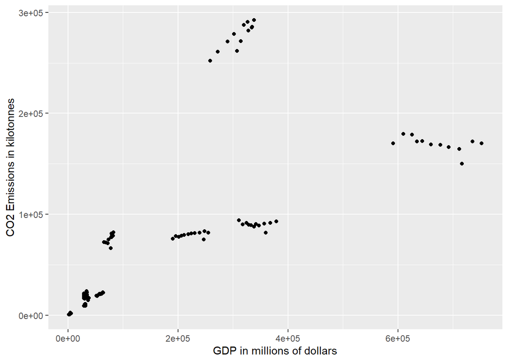

```r
a + geom_point()
```

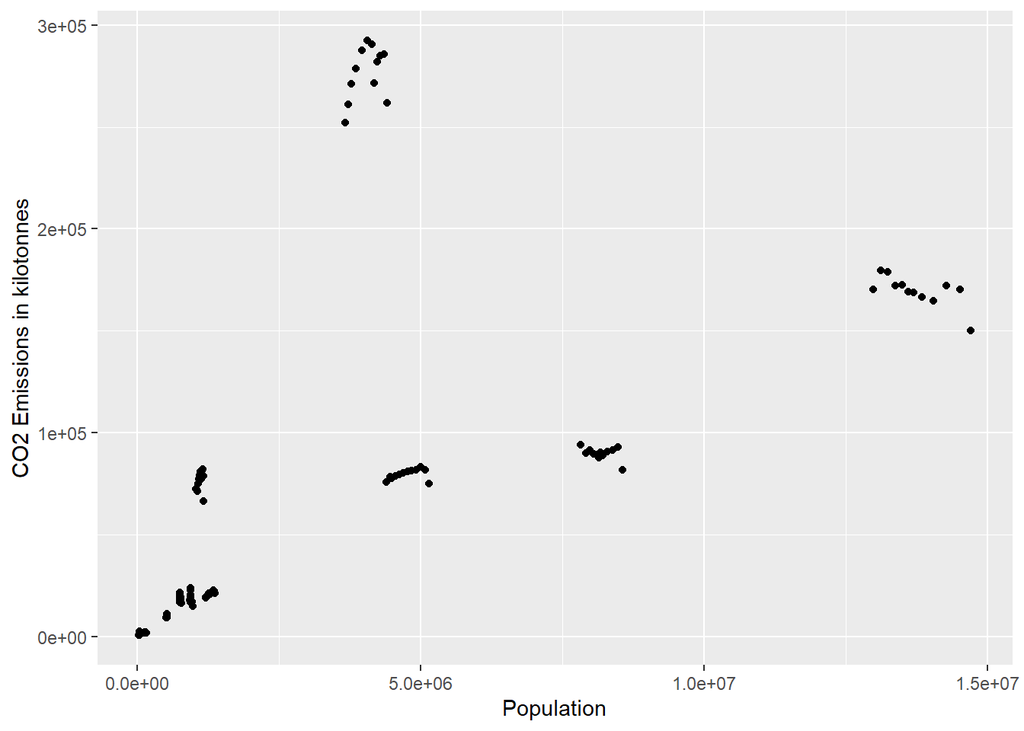

```r
b + geom_point()
```

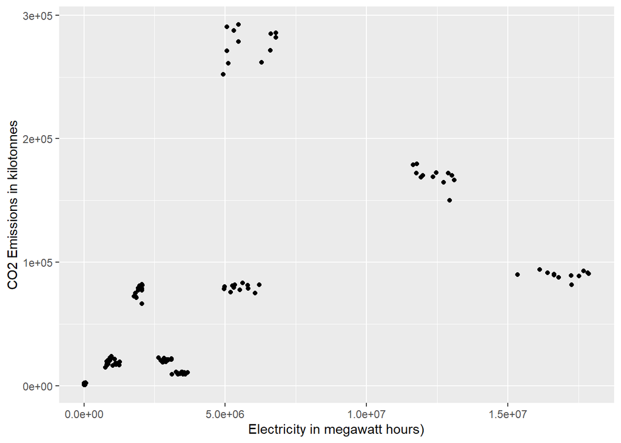

```r
c + geom_point()
```

```r
#create a summary table organized by province
sumtable(CO2_data,
      vars = c("gdp", "population", "electricity"),
       summ = c('mean(x)'),
       group = 'province',
       digits = 6,
       out = 'return')
```

```
     Variable    Mean    Mean    Mean    Mean     Mean     Mean    Mean    Mean
1    province       1       2       3       4        5        6       7       8
2         gdp 30867.9 5354.27 35442.1 29648.8   342227   671022 58235.8 76860.4
3  population  525234  147399  948649  762457  8181472 13744892 1289769 1112535
4 electricity 3421574 33549.2  861659 1081799 16943730 12382425 2904070 1948381
     Mean    Mean    Mean    Mean    Mean
1       9      10      11      12      13
2  310673  222483 2452.57 4518.11 2472.95
3 4057539 4751827 37614.6 44185.9 35973.2
4 5789208 5502451 37739.5 58013.7 15103.4
```

Let’s see what happens when we interact some of the terms.

```r
#Province interacted with population
mlr_5 <- lm(CO2 ~ gdp + electricity + population*province, data = CO2_data)
summary(mlr_5)
```

```
Call:
lm(formula = CO2 ~ gdp + electricity + population * province,
    data = CO2_data)

Residuals:
    Min      1Q  Median      3Q     Max
-9332.6  -296.7    -8.1   529.7  8933.2

Coefficients:
                        Estimate Std. Error t value Pr(>|t|)
(Intercept)           -5.129e+04  1.035e+05  -0.495 0.621114
gdp                    4.881e-01  3.171e-02  15.394  < 2e-16 ***
electricity           -2.535e-03  9.255e-04  -2.739 0.007045 **
population             1.046e-01  1.975e-01   0.529 0.597388
province2              5.470e+04  1.050e+05   0.521 0.603122
province3              2.144e+05  1.166e+05   1.839 0.068247 .
province4              1.875e+05  1.195e+05   1.569 0.119058
province5              3.623e+05  1.074e+05   3.372 0.000986 ***
province6              6.204e+05  1.065e+05   5.825 4.37e-08 ***
province7              6.796e+04  1.049e+05   0.648 0.518420
province8              1.052e+05  1.049e+05   1.002 0.318095
province9              2.318e+05  1.040e+05   2.227 0.027669 *
province10             2.066e+05  1.047e+05   1.973 0.050654 .
province11             5.186e+04  1.041e+05   0.498 0.619027
province12             4.885e+04  1.116e+05   0.438 0.662446
province13             5.202e+04  1.043e+05   0.499 0.618850
population:province2  -1.332e-01  2.299e-01  -0.579 0.563488
population:province3  -2.725e-01  2.056e-01  -1.326 0.187260
population:province4  -2.741e-01  2.123e-01  -1.291 0.199056
population:province5  -1.468e-01  1.973e-01  -0.744 0.458264
population:province6  -1.552e-01  1.975e-01  -0.786 0.433275
population:province7  -1.177e-01  1.979e-01  -0.595 0.553035
population:province8  -1.139e-01  1.980e-01  -0.575 0.566212
population:province9  -1.147e-01  1.973e-01  -0.581 0.562212
population:province10 -1.405e-01  1.975e-01  -0.711 0.478172
population:province11 -1.333e-01  3.432e-01  -0.388 0.698415
population:province12 -4.976e-02  9.665e-01  -0.051 0.959023
population:province13 -1.395e-01  4.091e-01  -0.341 0.733628
---
Signif. codes:  0 '***' 0.001 '**' 0.01 '*' 0.05 '.' 0.1 ' ' 1

Residual standard error: 2498 on 128 degrees of freedom
Multiple R-squared:  0.9992,    Adjusted R-squared:  0.999
F-statistic:  5826 on 27 and 128 DF,  p-value: < 2.2e-16
```

```r
#Province interacted with gdp
mlr_6 <- lm(CO2 ~ population + electricity + gdp*province, data = CO2_data)
summary(mlr_6)
```

```
Call:
lm(formula = CO2 ~ population + electricity + gdp * province,
    data = CO2_data)

Residuals:
    Min      1Q  Median      3Q     Max
-8326.6  -381.2     2.8   458.3  5158.7

Coefficients:
                 Estimate Std. Error t value Pr(>|t|)
(Intercept)     1.005e+04  2.093e+04   0.480  0.63180
population     -3.178e-02  2.460e-03 -12.919  < 2e-16 ***
electricity    -1.549e-03  6.764e-04  -2.290  0.02364 *
gdp             7.122e-01  6.782e-01   1.050  0.29570
province2      -5.698e+03  2.241e+04  -0.254  0.79969
province3       8.739e+04  2.622e+04   3.333  0.00112 **
province4       6.001e+04  3.141e+04   1.911  0.05825 .
province5       2.466e+05  2.484e+04   9.926  < 2e-16 ***
province6       4.385e+05  2.673e+04  16.408  < 2e-16 ***
province7       1.409e+04  2.242e+04   0.629  0.53066
province8       3.856e+04  2.241e+04   1.721  0.08774 .
province9       1.784e+05  2.224e+04   8.019 5.81e-13 ***
province10      1.323e+05  2.207e+04   5.994 1.95e-08 ***
province11     -9.304e+03  2.287e+04  -0.407  0.68480
province12     -7.810e+03  2.414e+04  -0.323  0.74686
province13     -9.361e+03  2.115e+04  -0.443  0.65876
gdp:province2  -3.183e-01  1.638e+00  -0.194  0.84627
gdp:province3  -2.040e+00  8.140e-01  -2.506  0.01348 *
gdp:province4  -1.570e+00  1.041e+00  -1.508  0.13400
gdp:province5  -3.633e-01  6.783e-01  -0.536  0.59317
gdp:province6  -4.483e-01  6.787e-01  -0.661  0.51007
gdp:province7   1.222e-02  6.931e-01   0.018  0.98596
gdp:province8   1.455e-01  6.861e-01   0.212  0.83243
gdp:province9   1.550e-02  6.784e-01   0.023  0.98181
gdp:province10 -2.776e-01  6.792e-01  -0.409  0.68344
gdp:province11 -2.626e-01  3.809e+00  -0.069  0.94513
gdp:province12 -4.268e-01  2.746e+00  -0.155  0.87673
gdp:province13 -2.600e-01  1.383e+00  -0.188  0.85118
---
Signif. codes:  0 '***' 0.001 '**' 0.01 '*' 0.05 '.' 0.1 ' ' 1

Residual standard error: 1869 on 128 degrees of freedom
Multiple R-squared:  0.9995,    Adjusted R-squared:  0.9994
F-statistic: 1.042e+04 on 27 and 128 DF,  p-value: < 2.2e-16
```

```r
mlr_7 <- lm(CO2 ~ population + electricity + gdp:province, data = CO2_data)
summary(mlr_7)
```

```
Call:
lm(formula = CO2 ~ population + electricity + gdp:province, data = CO2_data)

Residuals:
     Min       1Q   Median       3Q      Max
-31549.3  -1230.8    119.6   1433.9  12645.2

Coefficients:
                 Estimate Std. Error t value Pr(>|t|)
(Intercept)     1.940e+04  5.781e+03   3.356 0.001017 **
population      2.479e-02  3.008e-03   8.242 1.10e-13 ***
electricity    -4.542e-03  1.686e-03  -2.694 0.007929 **
gdp:province1  -2.209e-01  2.320e-01  -0.952 0.342657
gdp:province2  -3.938e+00  1.079e+00  -3.650 0.000369 ***
gdp:province3  -5.686e-01  1.494e-01  -3.806 0.000211 ***
gdp:province4  -4.955e-01  1.803e-01  -2.748 0.006780 **
gdp:province5  -1.623e-01  6.453e-02  -2.515 0.013043 *
gdp:province6  -2.007e-01  4.583e-02  -4.380 2.31e-05 ***
gdp:province7  -2.966e-01  9.859e-02  -3.009 0.003109 **
gdp:province8   4.945e-01  6.950e-02   7.115 5.32e-11 ***
gdp:province9   5.870e-01  2.874e-02  20.424  < 2e-16 ***
gdp:province10 -1.475e-01  4.504e-02  -3.275 0.001330 **
gdp:province11 -7.950e+00  2.400e+00  -3.312 0.001178 **
gdp:province12 -4.018e+00  1.303e+00  -3.083 0.002466 **
gdp:province13 -7.660e+00  2.316e+00  -3.307 0.001198 **
---
Signif. codes:  0 '***' 0.001 '**' 0.01 '*' 0.05 '.' 0.1 ' ' 1

Residual standard error: 4859 on 140 degrees of freedom
Multiple R-squared:  0.9966,    Adjusted R-squared:  0.9963
F-statistic:  2765 on 15 and 140 DF,  p-value: < 2.2e-16
```

```r
vif(mlr_7)
```

```
there are higher-order terms (interactions) in this model
consider setting type = 'predictor'; see ?vif
```

```
                   GVIF Df GVIF^(1/(2*Df))
population     930.5428  1       30.504800
electricity    479.2521  1       21.891827
gdp:province 62227.6486 13        1.528917
```

Now that we have a few different models, let’s compare some of our results.

```r
stargazer(mlr_1, mlr_2, mlr_3, mlr_4, mlr_5, mlr_6, mlr_7, title="Comparison of Muliple Regression Results",
          align = TRUE, type="text", keep.stat = c("n","rsq"))
```

```
Comparison of Muliple Regression Results
=============================================================================================================================
                                                                Dependent variable:
                      -------------------------------------------------------------------------------------------------------
                                                                        CO2
                          (1)            (2)             (3)            (4)            (5)            (6)            (7)
-----------------------------------------------------------------------------------------------------------------------------
gdp                     1.601***                       0.446***       0.447***       0.488***        0.712
                        (0.052)                        (0.044)        (0.045)        (0.032)        (0.678)

population             -0.072***                      -0.043***      -0.042***        0.105        -0.032***      0.025***
                        (0.003)                        (0.004)        (0.004)        (0.198)        (0.002)        (0.003)

per_capita_gdp                     1,181,707.000***
                                    (275,328.000)

electricity             0.007***       0.010***         0.001                       -0.003***       -0.002**      -0.005***
                        (0.001)        (0.001)         (0.001)                       (0.001)        (0.001)        (0.002)

province2                                            -8,715.716**  -12,657.660***   54,701.130     -5,698.181
                                                     (3,588.408)    (1,589.254)   (104,950.400)   (22,409.260)

province3                                           28,580.740***  24,477.550***   214,407.000*  87,391.290***
                                                     (3,971.206)    (2,135.841)   (116,594.900)   (26,219.690)

province4                                           22,621.500***  19,109.350***   187,504.800    60,012.200*
                                                     (3,372.956)    (1,778.792)   (119,486.700)   (31,405.210)

province5                                           253,686.500*** 259,660.400*** 362,302.500*** 246,554.500***
                                                     (20,213.450)   (19,650.820)  (107,433.500)   (24,838.720)

province6                                           433,624.300*** 424,413.600*** 620,438.800*** 438,499.700***
                                                     (31,190.820)   (30,324.170)  (106,520.500)   (26,725.360)

province7                                           32,350.330***  30,438.110***    67,959.810     14,094.200
                                                     (2,980.379)    (2,543.155)   (104,945.200)   (22,417.830)

province8                                           72,979.970***  70,024.700***   105,164.300    38,556.060*
                                                     (2,958.300)    (1,714.404)   (104,924.000)   (22,408.380)

```

[output cut: 83 more lines]

```

gdp:province12                                                                                       -0.427       -4.018***
                                                                                                    (2.746)        (1.303)

gdp:province13                                                                                       -0.260       -7.660***
                                                                                                    (1.383)        (2.316)

Constant              7,518.300***  -47,138.540***  14,385.140***  18,137.770***   -51,288.520     10,054.610   19,400.810***
                      (2,375.031)    (17,769.030)    (3,390.769)    (1,454.672)   (103,513.700)   (20,931.750)   (5,780.503)

-----------------------------------------------------------------------------------------------------------------------------
Observations              156            156             156            156            156            156            156
R2                       0.919          0.391           0.998          0.998          0.999          1.000          0.997
=============================================================================================================================
Note:                                                                                             *p<0.1; **p<0.05; ***p<0.01
```

From the results of our simple regression, we know that there is a strong relationship between between province and [$CO_2$] emissions. But to choose the best model based on the data we have, we need to consider the models holistically, paying attention to the common issues that arise in regression, and not just the explanatory power alone.

## Summary:

In conclusion, we note that CO2 Emissions in the Canadian Economy are severely impacted by the variables of our consideration: GDP, Electricity Generation, and Population. It is also important to note that we ought to explore our data by running multiple regressions, and clean it appropriately before running our analysis. This exploratory practice may lead us relationships that we expect, or something completely contrasting. Therefore, use this as a sample for your own project, and keep researching!

## Exercises:

The below exercises are intended to help you check your conceptual understanding of the content.

### Exercise 1:

What is an advantage of a multiple regression model over a simple regression model? Pick the best answer.

A: Multiple regression models often exhibit multicollinearity, which gives them better explanatory power compared to simple regressions.

B: Multiple regression models improve the predictive properties of a model by adding multiple regressors that play a role in the relationship.

C: Multiple regression models can display complicated relationships, but simple regression models are too simple to ever be useful.

D: By having multiple variables, multiple regressions allow us to see the interactions between different variables in a relationship.

```r
answer_1 <- '...' # your answer here ('A', 'B', 'C', or 'D')

test_1()
```

### Exercise 2:

Which of the below would *not* be a way of resolving heteroskedasticity within a regression model?

A: Performing a log transformation on the outcome variable

B: Using the appropriate code to generate HC1 standard errors

C: Searching for a different dataset to use

D: Adding more explanatory variables to the model (so long as all of the individual relationships remain significant)

```r
answer_2 <- '...' # your answer here ('A', 'B', 'C', or 'D')

test_2()
```

### Exercise 3:

What does a variance inflation factor of a variable tell us?

A: The magnitude of the heteroskedasticity (variance of error terms) in the data for a given variable.

B: The extent to which the variability of a dependent variable is inflated by multicollinearity in the model.

C: Whether or not there is multicollinearity in our model.

D: The extent to which the model is inflated by ommitted variable bias.

```r
answer_3 <- '...' # your answer here ('A', 'B', 'C', or 'D')

test_3()
```

### Exercise 4:

In what situation would it be appropriate to incorporate an interaction into your model? Pick the best answer.

A: There is reason to believe that the combined effect of two or more variables has an impact on the outcome variable.

B: There is reason to believe that the combined effect of two or more continuous variables has an impact on the outcome variable.

C: Your model is displaying multicollinearity with two variables.

D: Your model is boring, and you want to make it more interesting.

```r
answer_4 <- '...' # your answer here ('A', 'B', 'C', or 'D')

test_4()
```